# 5. házi feladat (HF5)

## 2. feladat (HF5/2)

Ebben a feladatban egy bútorkereskedés számára kell az ügyféladatokból értelmes és hasznos klasztereket találnod, hogy az egyes klaszterekben lévő ügyfeleknek célzott hirdetésket tudjanak kiküldeni! (3 pont)

**a)** Töltsd be az Adatok mappában található customer_survey.csv fájlt R-be. Használj két különböző, órán tanult klaszterező algoritmust, hogy megtaláld az értelmes klasztereket! (A klaszterező algoritmusokat nem kell neked megírnod, használd az R beépített függvényeit.) A cél jól használható klasztereket találni!

```r
customers <- read.csv("../Adatok/customer_survey.csv", sep=' ',header = TRUE)
head(customers)
```

```
##        age gender   income kids ownHome subscribe
## 1 47.31613   Male 49482.81    2   ownNo     subNo
## 2 31.38684   Male 35546.29    1  ownYes     subNo
## 3 43.20034   Male 44169.19    0  ownYes     subNo
## 4 37.31700 Female 81041.99    1   ownNo     subNo
## 5 40.95439 Female 79353.01    3  ownYes     subNo
## 6 43.03387   Male 58143.36    4  ownYes     subNo
```

```r
customers$gender[customers$gender == "Male"] <- 1
customers$gender[customers$gender == "Female"] <- 0
customers$ownHome[customers$ownHome == "ownYes"] <- 1
customers$ownHome[customers$ownHome == "ownNo"] <- 0
customers$subscribe[customers$subscribe == "subYes"] <- 1
customers$subscribe[customers$subscribe == "subNo"] <- 0
head(customers)
```

```
##        age gender   income kids ownHome subscribe
## 1 47.31613      1 49482.81    2       0         0
## 2 31.38684      1 35546.29    1       1         0
## 3 43.20034      1 44169.19    0       1         0
## 4 37.31700      0 81041.99    1       0         0
## 5 40.95439      0 79353.01    3       1         0
## 6 43.03387      1 58143.36    4       1         0
```

```r
# install.packages("dplyr")
library(dplyr)
```

```r
customers_clustering <- customers %>%
  mutate(age=scale(age),
         income=scale(income),
         kids=scale(kids))
head(customers_clustering)
```

```
##           age gender     income       kids ownHome subscribe
## 1  0.48133138      1 -0.0721898  0.5183027       0         0
## 2 -0.77221071      1 -0.7642562 -0.1917010       1         0
## 3  0.15744276      1 -0.3360563 -0.9017048       1         0
## 4 -0.30554218      0  1.4949908 -0.1917010       0         0
## 5 -0.01930052      0  1.4111190  1.2283065       1         0
## 6  0.14434200      1  0.3578800  1.9383103       1         0
```

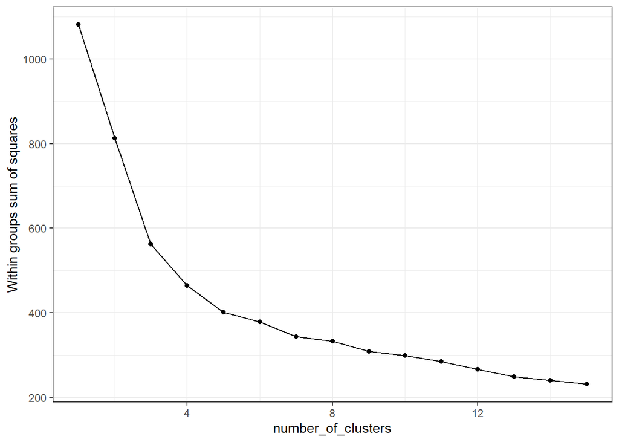

```r
#Az első feladatba van beillesztve a függvény.
elbow_method(customers_clustering, max_k=15)
```

```r
customers_clusters <- kmeans(customers_clustering, centers = 5, nstart=20)
customers_clusters
```

```
## K-means clustering with 5 clusters of sizes 105, 32, 51, 53, 59
##
## Cluster means:
##          age    gender     income        kids   ownHome  subscribe
## 1 -0.2512694 0.4095238  0.2418025 -0.07674804 0.3428571 0.14285714
## 2  1.3899304 0.4062500  1.6705105 -0.87951718 0.7500000 0.09375000
## 3 -0.1969461 0.4313725  0.2578261  1.70164235 0.4901961 0.09803922
## 4  1.1965373 0.5471698 -0.1528973 -0.86151591 0.7924528 0.13207547
## 5 -1.2113002 0.6101695 -1.4218843 -0.08339537 0.2372881 0.16949153
##
## Clustering vector:
##   [1] 1 5 4 1 3 3 5 1 1 1 4 1 1 3 1 3 1 4 1 1 4 3 1 1 3 1 1 1 1 1 4 3 1 3 1 1 3
##  [38] 1 5 1 1 3 1 1 1 1 3 1 3 5 1 1 3 3 3 3 1 1 5 3 1 1 3 1 1 1 1 3 1 1 1 1 4 1
##  [75] 3 3 1 3 4 1 2 3 1 1 1 1 1 3 3 1 3 1 1 3 3 3 1 1 3 5 5 5 5 5 5 5 5 5 5 5 5
## [112] 5 5 5 5 5 5 5 5 5 5 5 5 5 5 5 5 5 5 5 5 5 5 5 5 5 5 5 5 5 5 5 5 5 5 5 5 5
## [149] 5 5 2 4 5 2 4 4 2 1 4 4 4 2 2 2 4 4 2 4 4 4 2 4 4 4 4 4 4 4 2 4 2 4 2 2 4
## [186] 4 4 4 2 1 4 2 4 4 4 2 4 4 2 4 4 2 4 2 2 2 2 4 4 2 4 2 2 4 4 4 2 2 4 4 4 1
## [223] 2 4 2 2 4 2 2 4 1 3 3 1 3 1 5 3 1 3 1 1 1 1 1 3 1 3 1 1 1 1 3 1 3 1 3 3 1
## [260] 3 1 5 1 1 3 3 1 1 4 1 1 1 3 3 1 1 1 1 3 1 3 3 1 1 1 1 1 1 1 1 1 3 1 1 1 1
## [297] 1 1 1 3
##
## Within cluster sum of squares by cluster:
## [1] 126.77807  41.72717  73.06531  77.86684  81.58896
##  (between_SS / total_SS =  62.9 %)
##
## Available components:
##
## [1] "cluster"      "centers"      "totss"        "withinss"     "tot.withinss"
## [6] "betweenss"    "size"         "iter"         "ifault"
```

```r
#install.packages("ggplot2")
library(ggplot2)
#install.packages("gridExtra")
library(gridExtra)
```

```r
customers_clustering$cluster <- as.factor(customers_clusters$cluster)
```

```r
a3 <- ggplot(customers_clustering, aes(x=age, y=income, color=cluster)) + geom_point(size=1) + theme_bw()
a4 <- ggplot(customers_clustering, aes(x=age, y=kids, color=cluster)) + geom_point(size=1) + theme_bw()
a5 <- ggplot(customers_clustering, aes(x=income, y=kids, color=cluster)) + geom_point(size=1) + theme_bw()
```

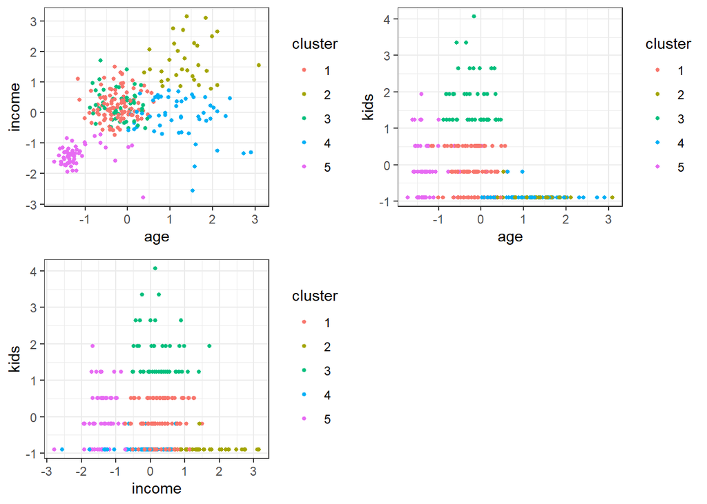

```r
grid.arrange(a3,a4,a5, nrow=2, ncol=2)
```